# СберАвтоподписка: прогноз целевого действия

ML-проект: подготовка событий веб-аналитики, исследование данных, обучение классификатора и сервис прогнозирования на FastAPI.

**Задача:** по источнику трафика, устройству и географии визита оценить вероятность целевого действия. Одна строка — визит; цель — хотя бы одно из восьми событий обращения или интереса, а не подтверждённая продажа.

**Данные:** учебный набор «СберАвтоподписка» (Skillbox), `ga_sessions.csv` и `ga_hits-002.csv`, период **19.05–31.12.2021**. Определение целевых событий приведено в разделе подготовки данных.

Сохранённые результаты доступны без запуска. Для повторения установите зависимости из `requirements.txt` и откройте ноутбук из корня проекта. `REBUILD_DATA=True` повторяет подготовку из CSV, `RETRAIN=True` — обучение и подбор. Расположение входных файлов описано в `README.md`.

### Основные результаты

Модель выбрана по ноябрю: **CatBoost с умеренными весами классов** (`tuned_sqrt_balanced`). На **366 245 декабрьских визитах** ROC-AUC = **0,5821**, Average Precision = **0,0314**. При пороге **0,0458** precision = **3,49%**, recall = **12,84%**.

Декабрь не используется для обучения, подбора параметров, весов или порога. Оценка показывает ограниченную устойчивость во времени: ориентир ROC-AUC **0,65 не достигнут**. Вариант с умеренными весами победил на ноябре, но уступил логистической регрессии и CatBoost без весов на декабре. Выбор по тесту не меняется; для следующего эксперимента требуется отдельный последующий период.

```python
from pathlib import Path
import sys, json, warnings
warnings.filterwarnings("ignore", message="Using `httpx` with `starlette.testclient` is deprecated.*")
import numpy as np
import pandas as pd
import matplotlib.pyplot as plt
from matplotlib.ticker import PercentFormatter, MaxNLocator, FuncFormatter
import seaborn as sns
from IPython.display import display, Markdown
ROOT = Path.cwd()
assert (ROOT / 'prepare.py').exists(), 'Откройте ноутбук из папки sberauto-conversion-ml'
sys.path.insert(0, str(ROOT))
from prepare import prepare_data, TARGET_ACTIONS
from features import RAW_FEATURES, CATEGORICAL, NUMERIC, make_features
from train import train_models, temporal_split
REBUILD_DATA = False
RETRAIN = False
SEED = 42
sns.set_theme(style='whitegrid', font='DejaVu Sans', font_scale=1.05)
plt.rcParams.update({'figure.figsize': (11, 5), 'figure.dpi': 110, 'axes.spines.top': False, 'axes.spines.right': False})
COLORS = ['#196785', '#C47924', '#687A37']
FIGURES = ROOT / 'reports/figures'
FIGURES.mkdir(exist_ok=True)
def savefig(name):
    plt.tight_layout()
    plt.savefig(FIGURES / (name + '.png'), dpi=140, bbox_inches='tight')
    plt.show()
```

## 1. Подготовка данных и контроль качества

CSV выбран вместо pickle: его можно читать частями, не загружая весь файл событий объёмом около 4 ГБ. PKL и CSV — альтернативные выгрузки; их не складываем как независимые наблюдения.

`prepare.py` читает все события блоками по 250 000 строк. Для каждого визита собираются признак наличия событий и `any(event_action in TARGET_ACTIONS)`. Это эквивалентно `groupby(session_id).max()` для бинарной цели. Затем метка присоединяется по идентификатору к единственной строке визита; количество строк не увеличивается.

Пропуски в UTM/устройстве сохраняются отдельной категорией `__MISSING__`, а не заполняются выдуманными значениями. `(none)` остаётся реальной категорией канала. `event_value` полностью пуст и не используется; `device_model` с >99% пропусков принимается API для совместимости, но исключён из модели. Повторы событий не меняют бинарную цель.

```python
sessions, audit = prepare_data(force=REBUILD_DATA)
display(pd.DataFrame({'Показатель': [
    'Сессии в исходнике', 'События в исходнике', 'Повторы строк сессий',
    'Повторы строк событий по хеш-аудиту', 'Визиты без событий',
    'ID событий без строки визита', 'Целевые ID без строки визита',
    'Целевые визиты после соединения'],
    'Значение': [audit[k] for k in [
        'sessions_raw','hits_raw','sessions_exact_duplicates','hits_hash_duplicate_rows',
        'sessions_without_hits','hit_sessions_without_session','target_sessions_without_session',
        'target_count_matched']]}))
assert len(sessions) == audit['sessions_raw'] - audit['sessions_exact_duplicates']
assert sessions.session_id.is_unique
assert sessions.target.isin([0,1]).all()
assert not sessions.loc[~sessions.has_hits, 'target'].any()
print('Целевые события:', ', '.join(TARGET_ACTIONS))
```

|  | Показатель | Значение |
| --- | --- | --- |
| 0 | Сессии в исходнике | 1860042 |
| 1 | События в исходнике | 15726470 |
| 2 | Повторы строк сессий | 0 |
| 3 | Повторы строк событий по хеш-аудиту | 0 |
| 4 | Визиты без событий | 127776 |
| 5 | ID событий без строки визита | 2344 |
| 6 | Целевые ID без строки визита | 446 |
| 7 | Целевые визиты после соединения | 50314 |

```
Целевые события: sub_car_claim_click, sub_car_claim_submit_click, sub_open_dialog_click, sub_custom_question_submit_click, sub_call_number_click, sub_callback_submit_click, sub_submit_success, sub_car_request_submit_click
```

**Интерпретация полноты.** Для визитов без событий нельзя доказать отсутствие целевого действия: неизвестен результат наблюдения. В общей статистике показаны обе оценки CR: по всем визитам (допущение «нет события = 0») и только по визитам с событиями. Для обучения выбрана вторая совокупность. Это может создавать смещение отбора; качество для визитов без событий отдельно не подтверждено. События без строки визита нельзя использовать в модели, поскольку нет входных признаков.

Хеш-аудит сравнивает все поля событий и находит ноль повторов. Нулевое число совпавших хешей означает отсутствие одинаковых строк; если совпадения появятся на новых данных, перед удалением нужно сравнить исходные строки, поскольку теоретически возможны коллизии.

|  | Доля пропусков | Уникальных значений |
| --- | --- | --- |
| device_model | 0.9912 | 104 |
| utm_keyword | 0.5817 | 1219 |
| device_os | 0.5753 | 13 |
| device_brand | 0.1974 | 205 |
| utm_adcontent | 0.1804 | 286 |
| utm_campaign | 0.1181 | 412 |
| utm_source | 0.0001 | 293 |
| geo_country | 0.0000 | 166 |
| device_browser | 0.0000 | 57 |
| device_screen_resolution | 0.0000 | 5039 |
| session_id | 0.0000 | 1860042 |
| device_category | 0.0000 | 3 |
| client_id | 0.0000 | 1391719 |
| utm_medium | 0.0000 | 56 |
| visit_number | 0.0000 | 537 |
| visit_time | 0.0000 | 85318 |
| visit_date | 0.0000 | 226 |
| geo_city | 0.0000 | 2548 |

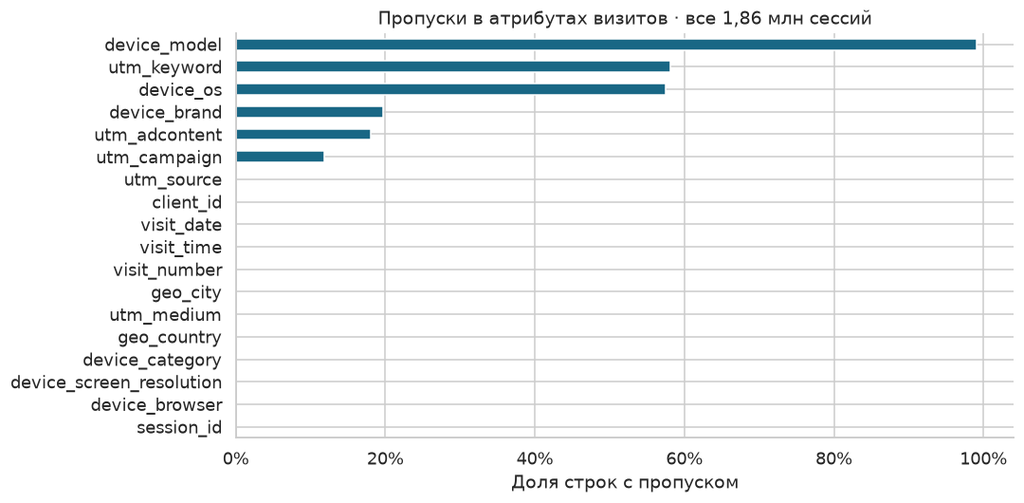

```
Полностью пустые поля событий: ['event_value']
```

```python
missing = pd.DataFrame({
    'Доля пропусков': pd.Series(audit['sessions_missing_fraction']),
    'Уникальных значений': pd.Series(audit['sessions_cardinality'])})
display(missing.sort_values('Доля пропусков', ascending=False).round(4))
fig, ax = plt.subplots(figsize=(10, 5))
missing['Доля пропусков'].sort_values().plot.barh(ax=ax, color=COLORS[0])
ax.xaxis.set_major_formatter(PercentFormatter(1))
ax.set(title='Пропуски в атрибутах визитов · все 1,86 млн сессий', xlabel='Доля строк с пропуском', ylabel='')
savefig('01_missing')
print('Полностью пустые поля событий:', [k for k,v in audit['hits_missing_fraction'].items() if v == 1])
```

## 2. Разведочный анализ

Ключевые разрезы: динамика визитов и событий, целевая метка, устройства, каналы, география, количество повторных визитов и числовые связи. CR считается по визитам, а не по числу событий. Различия сегментов описательные; причинных выводов о рекламе по ним не делаем.

```
CR среди всех визитов: 2.705%
CR среди визитов с событиями: 2.905%
```

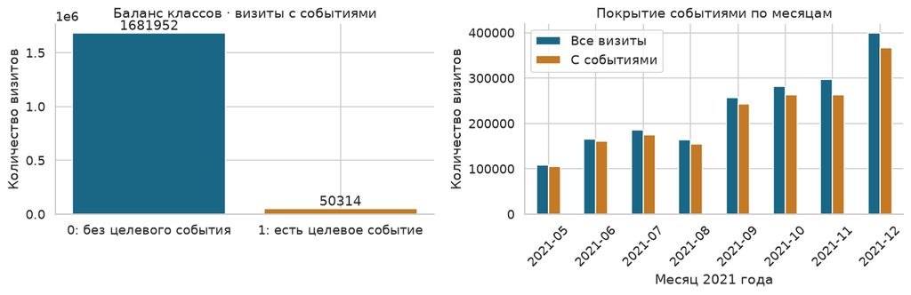

| visit_date | visits | observed_visits | targets | CR_observed | missing_hits_fraction |
| --- | --- | --- | --- | --- | --- |
| 2021-05 | 108202 | 104591 | 6428 | 0.0615 | 0.0334 |
| 2021-06 | 166470 | 160622 | 6609 | 0.0411 | 0.0351 |
| 2021-07 | 185244 | 174708 | 4887 | 0.0280 | 0.0569 |
| 2021-08 | 164155 | 155003 | 5498 | 0.0355 | 0.0558 |
| 2021-09 | 257478 | 243803 | 6035 | 0.0248 | 0.0531 |
| 2021-10 | 281622 | 263459 | 7114 | 0.0270 | 0.0645 |
| 2021-11 | 297769 | 263835 | 6444 | 0.0244 | 0.1140 |
| 2021-12 | 399102 | 366245 | 7299 | 0.0199 | 0.0823 |

```python
observed = sessions.loc[sessions.has_hits].copy()
print(f"CR среди всех визитов: {sessions.target.mean():.3%}")
print(f"CR среди визитов с событиями: {observed.target.mean():.3%}")
fig, axes = plt.subplots(1, 2, figsize=(12, 4))
counts = observed.target.value_counts().sort_index()
axes[0].bar(['0: без целевого события', '1: есть целевое событие'], counts, color=[COLORS[0], COLORS[1]])
axes[0].bar_label(axes[0].containers[0], fmt='%d')
axes[0].set(title='Баланс классов · визиты с событиями', ylabel='Количество визитов')
monthly = sessions.groupby(sessions.visit_date.dt.to_period('M')).agg(
    visits=('session_id','size'), observed_visits=('has_hits','sum'), targets=('target','sum'))
monthly['CR_observed'] = monthly.targets / monthly.observed_visits
monthly['missing_hits_fraction'] = 1 - monthly.observed_visits / monthly.visits
monthly.index = monthly.index.astype(str)
monthly[['visits','observed_visits']].plot.bar(ax=axes[1], color=COLORS[:2], rot=0)
axes[1].set(title='Покрытие событиями по месяцам', ylabel='Количество визитов', xlabel='Месяц 2021 года')
axes[1].legend(['Все визиты', 'С событиями'])
axes[1].tick_params(axis='x', labelrotation=45)
savefig('02_target_coverage')
display(monthly.round(4))
```

Редкий положительный класс делает accuracy вводящей в заблуждение: постоянный прогноз 0 будет верен примерно в 97% случаев, но не найдёт ни одного целевого визита. Основная метрика качества — ROC-AUC; дополнительно оцениваем Average Precision (площадь под PR-кривой в определении AP), precision, recall, F1 и матрицу ошибок. Май в выгрузке неполный, поэтому его объём нельзя напрямую сравнивать с полным месяцем.

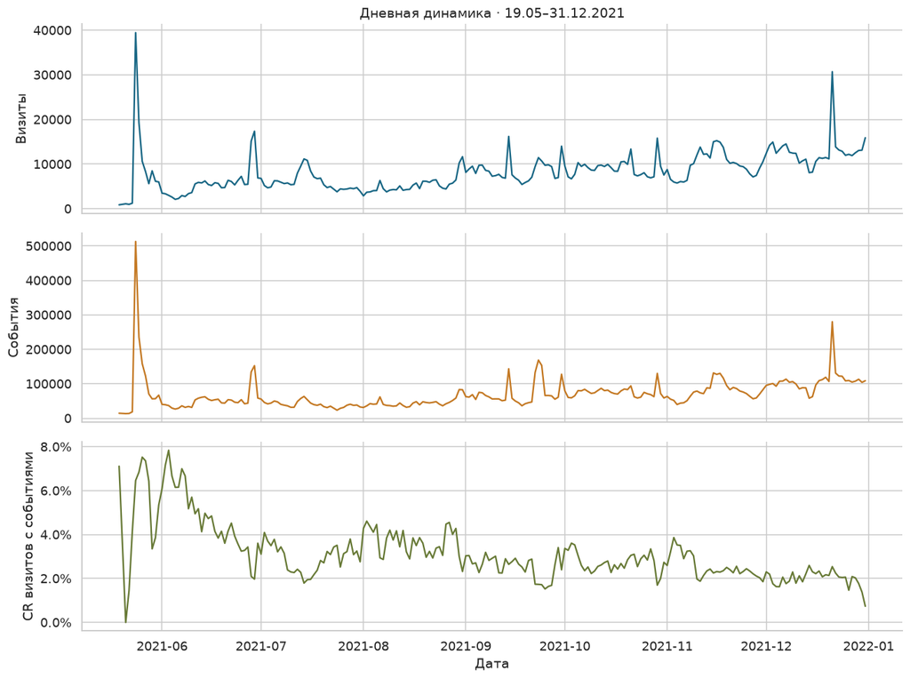

```python
daily = sessions.groupby('visit_date').agg(visits=('session_id','size'), observed_visits=('has_hits','sum'), targets=('target','sum'))
hit_daily = pd.read_csv(ROOT/'reports/hits_daily.csv', parse_dates=['date']).set_index('date')
fig, axes = plt.subplots(3, 1, figsize=(12, 9), sharex=True)
axes[0].plot(daily.index, daily.visits, color=COLORS[0]); axes[0].set(ylabel='Визиты', title='Дневная динамика · 19.05–31.12.2021')
axes[1].plot(hit_daily.index, hit_daily['count'], color=COLORS[1]); axes[1].set(ylabel='События')
axes[2].plot(daily.index, daily.targets.div(daily.observed_visits.replace(0,np.nan)), color=COLORS[2])
axes[2].yaxis.set_major_formatter(PercentFormatter(1))
axes[2].set(ylabel='CR визитов с событиями', xlabel='Дата')
savefig('03_daily')
```

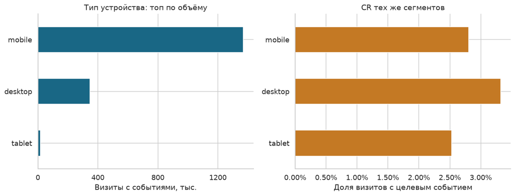

| segment | visits | target_visits | CR |
| --- | --- | --- | --- |
| mobile | 1368679 | 38379 | 0.0280 |
| desktop | 346891 | 11513 | 0.0332 |
| tablet | 16696 | 422 | 0.0253 |

Больше всего наблюдаемых визитов в этом разрезе: **mobile** — **1,368,679** (79.0% от совокупности). Максимальный CR среди показанных крупных сегментов у **desktop**: **3.32%**. Это описательное сравнение, не эффект изменения канала или устройства.

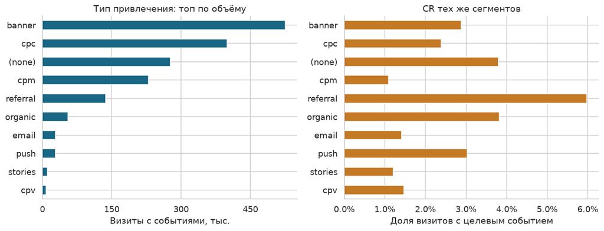

| segment | visits | target_visits | CR |
| --- | --- | --- | --- |
| banner | 525206 | 15107 | 0.0288 |
| cpc | 399395 | 9529 | 0.0239 |
| (none) | 277060 | 10531 | 0.0380 |
| cpm | 229791 | 2519 | 0.0110 |
| referral | 136851 | 8181 | 0.0598 |
| organic | 55009 | 2100 | 0.0382 |
| email | 28287 | 401 | 0.0142 |
| push | 27710 | 840 | 0.0303 |
| stories | 10472 | 126 | 0.0120 |
| cpv | 7815 | 115 | 0.0147 |

Больше всего наблюдаемых визитов в этом разрезе: **banner** — **525,206** (30.3% от совокупности). Максимальный CR среди показанных крупных сегментов у **referral**: **5.98%**. Это описательное сравнение, не эффект изменения канала или устройства.

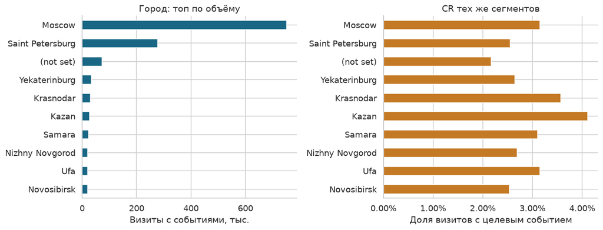

| segment | visits | target_visits | CR |
| --- | --- | --- | --- |
| Moscow | 750928 | 23629 | 0.0315 |
| Saint Petersburg | 278402 | 7113 | 0.0255 |
| (not set) | 73297 | 1588 | 0.0217 |
| Yekaterinburg | 33555 | 887 | 0.0264 |
| Krasnodar | 30260 | 1081 | 0.0357 |
| Kazan | 27689 | 1139 | 0.0411 |
| Samara | 23433 | 727 | 0.0310 |
| Nizhny Novgorod | 20782 | 559 | 0.0269 |
| Ufa | 20283 | 639 | 0.0315 |
| Novosibirsk | 20115 | 509 | 0.0253 |

Больше всего наблюдаемых визитов в этом разрезе: **Moscow** — **750,928** (43.3% от совокупности). Максимальный CR среди показанных крупных сегментов у **Kazan**: **4.11%**. Это описательное сравнение, не эффект изменения канала или устройства.

```python
def segment_table(column, top=10):
    table = observed.assign(segment=observed[column].fillna('__MISSING__')).groupby('segment').target.agg(['size','sum','mean'])
    table.columns = ['visits', 'target_visits', 'CR']
    return table.sort_values('visits', ascending=False).head(top)
for column, title in [('device_category','Тип устройства'), ('utm_medium','Тип привлечения'), ('geo_city','Город')]:
    table = segment_table(column)
    fig, axes = plt.subplots(1, 2, figsize=(12, 4.7))
    table['visits'].sort_values().plot.barh(ax=axes[0], color=COLORS[0])
    table['CR'].reindex(table['visits'].sort_values().index).plot.barh(ax=axes[1], color=COLORS[1])
    axes[0].set(title=f'{title}: топ по объёму', xlabel='Визиты с событиями', ylabel='')
    axes[1].set(title='CR тех же сегментов', xlabel='Доля визитов с целевым событием', ylabel='')
    axes[0].xaxis.set_major_locator(MaxNLocator(4))
    axes[0].xaxis.set_major_formatter(FuncFormatter(lambda x, pos: f'{x/1000:.0f}'))
    axes[0].set_xlabel('Визиты с событиями, тыс.')
    axes[1].xaxis.set_major_formatter(PercentFormatter(1))
    savefig('04_segments_' + column)
    display(table.round(4))
    largest = table.iloc[0]
    best_cr = table.CR.idxmax()
    display(Markdown(f'Больше всего наблюдаемых визитов в этом разрезе: **{table.index[0]}** — **{int(largest.visits):,}** ({largest.visits/len(observed):.1%} от совокупности). Максимальный CR среди показанных крупных сегментов у **{best_cr}**: **{table.loc[best_cr, "CR"]:.2%}**. Это описательное сравнение, не эффект изменения канала или устройства.'))
```

```python
for column in ['utm_source','utm_campaign','device_category','geo_city']:
    table = segment_table(column, top=10000)
    leaders = table.loc[table.visits >= 1000].sort_values('CR', ascending=False).head(3)
    display(Markdown(f'**{column}: лидеры CR среди сегментов с ≥1000 наблюдаемыми визитами**'))
    display(leaders.round(4))
print('Порог 1000 ограничивает шум малых групп, но не заменяет статистической проверки. Хеши кампаний не раскрывают их содержание.')
```

**utm_source: лидеры CR среди сегментов с ≥1000 наблюдаемыми визитами**

| segment | visits | target_visits | CR |
| --- | --- | --- | --- |
| oZCzWSykfixnjMPDNjSU | 2585 | 260 | 0.1006 |
| BKeImrJuRDZcHiSSTdzm | 1335 | 98 | 0.0734 |
| aXQzDWsJuGXeBXexNHjc | 29528 | 1827 | 0.0619 |

**utm_campaign: лидеры CR среди сегментов с ≥1000 наблюдаемыми визитами**

| segment | visits | target_visits | CR |
| --- | --- | --- | --- |
| EiQppLFrUZrUsjXVulLg | 1244 | 110 | 0.0884 |
| WJUKqfeOrjXIOHjgcgdR | 1137 | 76 | 0.0668 |
| DsqwamlMwRgMTyspCjFR | 2700 | 172 | 0.0637 |

**device_category: лидеры CR среди сегментов с ≥1000 наблюдаемыми визитами**

| segment | visits | target_visits | CR |
| --- | --- | --- | --- |
| desktop | 346891 | 11513 | 0.0332 |
| mobile | 1368679 | 38379 | 0.0280 |
| tablet | 16696 | 422 | 0.0253 |

**geo_city: лидеры CR среди сегментов с ≥1000 наблюдаемыми визитами**

| segment | visits | target_visits | CR |
| --- | --- | --- | --- |
| Domodedovo | 3729 | 263 | 0.0705 |
| Makhachkala | 2455 | 139 | 0.0566 |
| Nalchik | 1028 | 52 | 0.0506 |

```
Порог 1000 ограничивает шум малых групп, но не заменяет статистической проверки. Хеши кампаний не раскрывают их содержание.
```

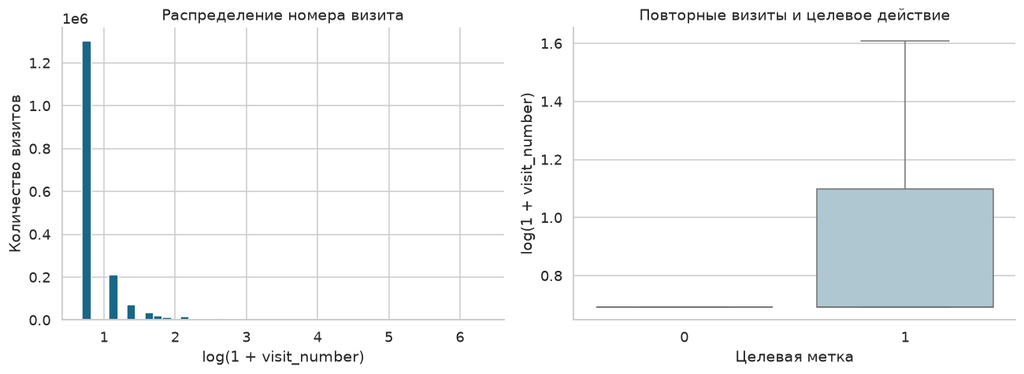

| target | count | mean | std | min | 25% | 50% | 75% | max |
| --- | --- | --- | --- | --- | --- | --- | --- | --- |
| 0 | 1681952.0 | 2.57 | 10.92 | 1.0 | 1.0 | 1.0 | 1.0 | 564.0 |
| 1 | 50314.0 | 4.51 | 25.98 | 1.0 | 1.0 | 1.0 | 2.0 | 562.0 |

```python
fig, axes = plt.subplots(1, 2, figsize=(12, 4.5))
# Для визуализации длинного хвоста используется log1p, наблюдения не удаляются.
axes[0].hist(np.log1p(observed.visit_number), bins=45, color=COLORS[0], edgecolor='white')
axes[0].set(title='Распределение номера визита', xlabel='log(1 + visit_number)', ylabel='Количество визитов')
sns.boxplot(data=observed.assign(log_visit=np.log1p(observed.visit_number)), x='target', y='log_visit', ax=axes[1], color='#A8C9D6', showfliers=False)
axes[1].set(title='Повторные визиты и целевое действие', xlabel='Целевая метка', ylabel='log(1 + visit_number)')
savefig('05_visit_distribution')
display(observed.groupby('target').visit_number.describe().round(2))
```

Номер визита доступен в исходной таблице и полезен для EDA, но не включён в сервис: сервис работает с `utm_*`, `device_*`, `geo_*`. Аналогично исключены идентификаторы и календарное время. Любые атрибуты `event_*`, страницы, число/время событий и `has_hits` используются только для разметки или аудита, поскольку они становятся известны во время/после визита.

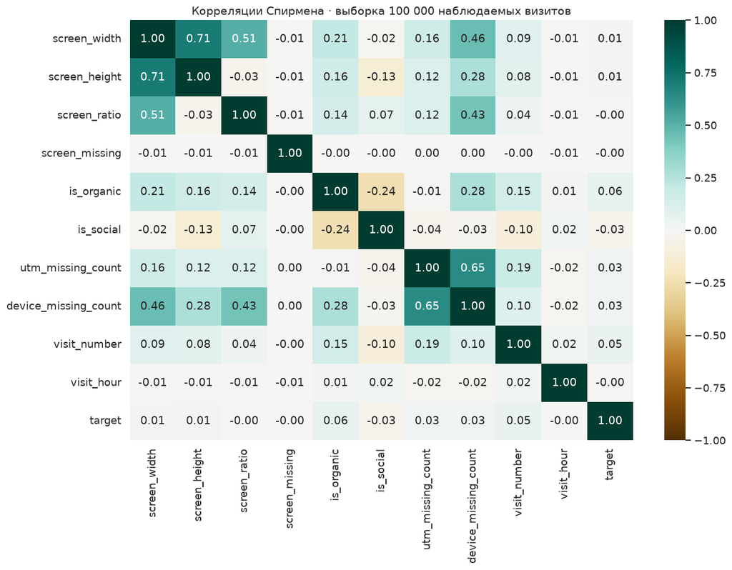

```
screen_width  screen_height    0.70814
Name: Spearman rho, dtype: float64
```

```
is_organic              0.063
visit_number            0.049
is_social              -0.031
device_missing_count    0.031
utm_missing_count       0.029
screen_height           0.014
screen_width            0.008
visit_hour             -0.003
screen_ratio           -0.003
screen_missing         -0.001
Name: target, dtype: float64
```

```python
eda_sample = observed.sample(n=min(100000,len(observed)), random_state=SEED)
engineered = make_features(eda_sample)
numeric = engineered[NUMERIC].copy()
numeric['visit_number'] = eda_sample.visit_number
numeric['visit_hour'] = eda_sample.visit_hour
numeric['target'] = eda_sample.target
corr = numeric.corr(method='spearman')
fig, ax = plt.subplots(figsize=(12, 9))
sns.heatmap(corr, vmin=-1, vmax=1, center=0, cmap='BrBG', annot=True, fmt='.2f', ax=ax)
ax.set_title('Корреляции Спирмена · выборка 100 000 наблюдаемых визитов')
savefig('06_correlations')
pairs = corr.where(np.triu(np.ones(corr.shape), k=1).astype(bool)).stack()
display(pairs.loc[pairs.abs() >= .65].sort_values(key=abs, ascending=False).rename('Spearman rho'))
display(corr.target.drop('target').sort_values(key=abs, ascending=False).round(3))
```

Разрешение и его производные закономерно связаны, а счётчики пропусков отражают качество трекинга и тип устройства. Корреляция не означает причинность; отсутствие сильной монотонной связи с целью не исключает нелинейные взаимодействия. Категориям не присваиваются произвольные числовые коды для корреляционного анализа. L2-регуляризация стабилизирует линейную модель при зависимых признаках; деревья CatBoost могут работать с ними, но индивидуальная важность при этом распределяется между связанными полями.

## 3. Временное разбиение и защита от утечки

Оценивается перенос модели на следующий месяц:

- train: 19 мая — 31 октября 2021;
- validation: 1–30 ноября, выбор настроек, ранняя остановка и порог;
- test: 1–31 декабря, итоговая оценка после фиксации выбора.

Повторный клиент в следующем месяце допустим и соответствует будущему потоку визитов. В признаках нет ID, даты, событий, `has_hits` или статистик будущих визитов. Декабрь отдельно разбит на новых клиентов (не встречались до 1 декабря) и возвращающихся.

Это ретроспективная проверка на историческом наборе данных, а не проспективный эксперимент. Для внешней проверки потребуются данные следующих периодов.

```python
model_data = observed.sort_values(['visit_date','session_id']).reset_index(drop=True)
splits = temporal_split(model_data)
assert np.all(sum(mask.astype(int) for mask in splits.values()) == 1)
assert model_data.loc[splits['train'],'visit_date'].max() < model_data.loc[splits['validation'],'visit_date'].min()
assert model_data.loc[splits['validation'],'visit_date'].max() < model_data.loc[splits['test'],'visit_date'].min()
results = train_models(force=RETRAIN)
display(pd.DataFrame(results['split']).T)
display(pd.Series(results['client_overlap'], name='Клиенты'))
selected = results['selected_model']
final = results['test'][selected]
LABELS = {'constant_baseline':'Константа', 'logistic_regression':'Логистическая регрессия',
          'temporal_baseline':'CatBoost: базовая конфигурация', 'tuned_unweighted':'Random search: без весов',
          'tuned_sqrt_balanced':'Random search: умеренный вес', 'tuned_balanced':'Random search: полный вес'}
print('Модель выбрана по ноябрю:', selected)
```

|  | rows | clients | positives | positive_rate | date_min | date_max |
| --- | --- | --- | --- | --- | --- | --- |
| train | 1102186 | 822012 | 36571 | 0.03318 | 2021-05-19 | 2021-10-31 |
| validation | 263835 | 211063 | 6444 | 0.024424 | 2021-11-01 | 2021-11-30 |
| test | 366245 | 312218 | 7299 | 0.019929 | 2021-12-01 | 2021-12-31 |

```
train_validation          9455
train_test                7664
new_december_clients    297084
Name: Клиенты, dtype: int64
```

```
Модель выбрана по ноябрю: tuned_sqrt_balanced
```

### Что изменяется во времени

Сравниваем долю целевых визитов по месяцам и распределения входных категорий. Jensen–Shannon divergence находится в диапазоне 0–1: 0 означает совпадающие распределения; большее значение — большее различие. Это описательная мера, не статистический тест и не доказательство причины изменений. Также считаем долю категорий, которых не было на train.

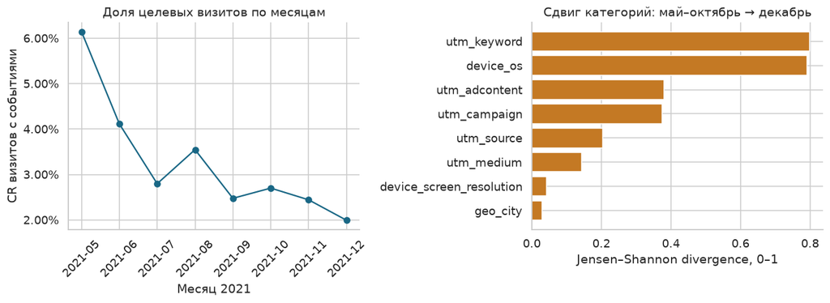

|  | month | sessions | target_sessions | CR |
| --- | --- | --- | --- | --- |
| 0 | 2021-05 | 104591 | 6428 | 0.0615 |
| 1 | 2021-06 | 160622 | 6609 | 0.0411 |
| 2 | 2021-07 | 174708 | 4887 | 0.0280 |
| 3 | 2021-08 | 155003 | 5498 | 0.0355 |
| 4 | 2021-09 | 243803 | 6035 | 0.0248 |
| 5 | 2021-10 | 263459 | 7114 | 0.0270 |
| 6 | 2021-11 | 263835 | 6444 | 0.0244 |
| 7 | 2021-12 | 366245 | 7299 | 0.0199 |

|  | feature | period | js_divergence_bits | unseen_fraction |
| --- | --- | --- | --- | --- |
| 9 | utm_keyword | test | 0.7981 | 0.1912 |
| 13 | device_os | test | 0.7919 | 0.0000 |
| 7 | utm_adcontent | test | 0.3799 | 0.4352 |
| 5 | utm_campaign | test | 0.3752 | 0.2043 |
| 1 | utm_source | test | 0.2042 | 0.0848 |
| 3 | utm_medium | test | 0.1437 | 0.0002 |
| 17 | device_screen_resolution | test | 0.0429 | 0.0079 |
| 23 | geo_city | test | 0.0292 | 0.0007 |
| 15 | device_brand | test | 0.0245 | 0.0001 |
| 19 | device_browser | test | 0.0173 | 0.0000 |
| 11 | device_category | test | 0.0137 | 0.0000 |
| 21 | geo_country | test | 0.0015 | 0.0000 |
| 12 | device_os | validation | 0.7921 | 0.0000 |
| 8 | utm_keyword | validation | 0.7739 | 0.1885 |
| 6 | utm_adcontent | validation | 0.2254 | 0.2277 |
| 4 | utm_campaign | validation | 0.2217 | 0.1015 |
| 0 | utm_source | validation | 0.1072 | 0.0593 |
| 2 | utm_medium | validation | 0.0656 | 0.0109 |
| 16 | device_screen_resolution | validation | 0.0149 | 0.0019 |
| 22 | geo_city | validation | 0.0120 | 0.0009 |
| 18 | device_browser | validation | 0.0081 | 0.0000 |
| 14 | device_brand | validation | 0.0068 | 0.0000 |
| 10 | device_category | validation | 0.0024 | 0.0000 |
| 20 | geo_country | validation | 0.0010 | 0.0000 |

CR в ноябре **2.44%**, в декабре **1.99%**. Поэтому нужно отслеживать не только ROC-AUC, но и полноту, точность и выбранный порог во времени.

```python
population = pd.read_csv(ROOT/'reports/monthly_population.csv')
drift = pd.read_csv(ROOT/'reports/feature_drift.csv')
fig, axes = plt.subplots(1,2,figsize=(12,4.5))
axes[0].plot(population.month,population.CR,marker='o',color=COLORS[0])
axes[0].set(title='Доля целевых визитов по месяцам',xlabel='Месяц 2021',ylabel='CR визитов с событиями')
axes[0].yaxis.set_major_formatter(PercentFormatter(1))
axes[0].tick_params(axis='x',labelrotation=45)
shift = drift.query("period == 'test'").sort_values('js_divergence_bits').tail(8)
axes[1].barh(shift.feature,shift.js_divergence_bits,color=COLORS[1])
axes[1].set(title='Сдвиг категорий: май–октябрь → декабрь',xlabel='Jensen–Shannon divergence, 0–1',ylabel='')
savefig('11_temporal_drift')
display(population.round(4))
display(drift.sort_values(['period','js_divergence_bits'],ascending=[True,False]).round(4))
display(Markdown(f"CR в ноябре **{results['split']['validation']['positive_rate']:.2%}**, в декабре **{results['split']['test']['positive_rate']:.2%}**. Поэтому нужно отслеживать не только ROC-AUC, но и полноту, точность и выбранный порог во времени."))
```

## 4. Признаки и поиск настроек

Используются 12 категориальных признаков `utm_*`, `device_*`, `geo_*` (без почти пустого `device_model`) и 8 производных: размеры/отношение сторон/неизвестное разрешение, organic/social, счётчики пропусков. Преобразования детерминированы. Энкодер и масштабирование логистической регрессии обучаются только на train; CatBoost видит целевые метки только train при обучении.

**RandomizedSearchCV:** шесть случайно выбранных комбинаций глубины, числа деревьев, скорости обучения, L2-регуляризации и случайности выбора разбиений; seed=42. Для ограничения времени используются стратифицированные выборки: 250 000 строк из train и 80 000 из ноября. Единственный `PredefinedSplit` явно сохраняет хронологическую границу. `refit=False` не позволяет автоматически обучить модель на объединённых train+validation. Это ограниченный поиск, а не полный перебор и не многократная временная кросс-валидация.

Лучший набор по ROC-AUC на ноябрьской подвыборке затем обучается на **всём train** и проверяется на **всём ноябре**. Базовая конфигурация CatBoost обучается на том же train. Это позволяет сравнить результаты базовой конфигурации и поиска параметров на одинаковых выборках.

```python
search = pd.read_csv(ROOT/'reports/random_search.csv')
parameters = pd.json_normalize(search.params.map(json.loads))
display(pd.concat([parameters, search.drop(columns='params')],axis=1).sort_values('validation_roc_auc',ascending=False).round(5))
print('Лучшие параметры ограниченного поиска:', results['random_search']['best_params'])
print('Число комбинаций:', results['random_search']['n_iter'])
print('Размеры выборок:', results['random_search']['train_sample'], results['random_search']['validation_sample'])
```

|  | depth | iterations | l2_leaf_reg | learning_rate | random_strength | validation_roc_auc | validation_ap | fit_seconds |
| --- | --- | --- | --- | --- | --- | --- | --- | --- |
| 0 | 6 | 200 | 3 | 0.12 | 1.5 | 0.59977 | 0.03690 | 31.66899 |
| 3 | 6 | 200 | 7 | 0.12 | 1.5 | 0.59852 | 0.03530 | 32.12732 |
| 1 | 4 | 200 | 7 | 0.12 | 0.5 | 0.59633 | 0.03373 | 22.47617 |
| 4 | 5 | 350 | 7 | 0.08 | 0.5 | 0.59476 | 0.03396 | 50.35183 |
| 2 | 4 | 200 | 3 | 0.12 | 0.5 | 0.59338 | 0.03331 | 22.32196 |
| 5 | 5 | 350 | 12 | 0.04 | 1.5 | 0.58044 | 0.03304 | 44.21622 |

```
Лучшие параметры ограниченного поиска: {'random_strength': 1.5, 'learning_rate': 0.12, 'l2_leaf_reg': 3, 'iterations': 200, 'depth': 6}
Число комбинаций: 6
Размеры выборок: 250000 80000
```

## 5. Дисбаланс классов: веса и порог

Целевое действие встречается редко. Сравниваются три варианта с **одинаковыми найденными гиперпараметрами**:

1. без весов: ошибка в каждом классе имеет одинаковый вес;
2. умеренный вес класса 1: `sqrt(N0/N1)`;
3. полный вес: `N0/N1`, уравнивающий суммарный вес двух классов на train.

Веса рассчитаны только по train. Синтетические визиты не создаются, исходный баланс validation/test не меняется. Веса могут улучшить поиск редкой цели, но также увеличить ложные срабатывания — преимущество не предполагается заранее.

После взвешенного обучения выход `q` отражает изменённое соотношение классов. Применяем фиксированную поправку `p = q / (w × (1−q) + q)` и используем её одинаково в отчёте и API. Она сохраняет ранжирование и ROC-AUC, но **не заменяет эмпирическую калибровку**. На test дополнительно показаны Brier score и калибровочный график.

**Правило выбора:** максимальный ROC-AUC полного ноября среди линейной модели и четырёх CatBoost; AP разрешает точное равенство. Выбор и контрольная сумма модели сохранены в `selection_frozen_before_test.json` до оценки декабря.

|  | roc_auc | pr_auc_ap | precision | recall | f1 | threshold | brier_score |
| --- | --- | --- | --- | --- | --- | --- | --- |
| logistic_regression | 0.59951 | 0.03434 | 0.03467 | 0.40348 | 0.06386 | 0.03828 | 0.02398 |
| temporal_baseline | 0.59401 | 0.04552 | 0.06899 | 0.08364 | 0.07561 | 0.05385 | 0.02371 |
| tuned_unweighted | 0.60270 | 0.04696 | 0.05242 | 0.11220 | 0.07146 | 0.04802 | 0.02367 |
| tuned_sqrt_balanced | 0.61145 | 0.04537 | 0.05042 | 0.14463 | 0.07478 | 0.04580 | 0.02369 |
| tuned_balanced | 0.59434 | 0.04684 | 0.07552 | 0.10382 | 0.08744 | 0.04955 | 0.02375 |

|  | model | positive_weight | tree_count | fit_seconds |
| --- | --- | --- | --- | --- |
| 0 | logistic_regression | 1.000 | NaN | 16.290 |
| 1 | temporal_baseline | 1.000 | 155.0 | 136.015 |
| 2 | tuned_unweighted | 1.000 | 194.0 | 155.526 |
| 3 | tuned_sqrt_balanced | 5.398 | 174.0 | 167.909 |
| 4 | tuned_balanced | 29.138 | 193.0 | 171.396 |

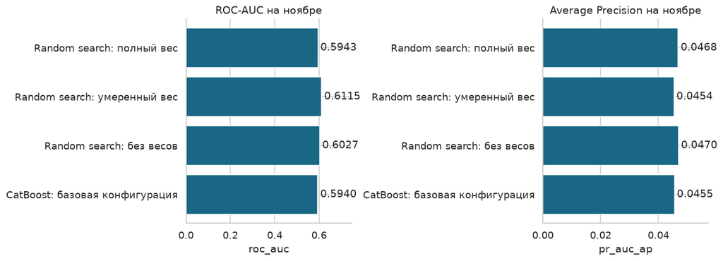

```python
validation = pd.DataFrame(results['validation']).T
columns = ['roc_auc','pr_auc_ap','precision','recall','f1','threshold','brier_score']
display(validation[columns].astype(float).round(5))
weights = pd.DataFrame([{'model':name,'positive_weight':value['positive_class_weight'],'tree_count':value['tree_count'],'fit_seconds':value['seconds']} for name,value in results['candidates'].items()])
display(weights.round(3))
fig, axes = plt.subplots(1,2,figsize=(12,4.5))
comparison = validation.reindex(['temporal_baseline','tuned_unweighted','tuned_sqrt_balanced','tuned_balanced'])
for ax,metric,title in zip(axes,['roc_auc','pr_auc_ap'],['ROC-AUC на ноябре','Average Precision на ноябре']):
    values = comparison[metric].astype(float)
    ax.barh([LABELS[x] for x in values.index],values,color=COLORS[0])
    ax.bar_label(ax.containers[0],fmt='%.4f',padding=3)
    ax.set(title=title,xlabel=metric,xlim=(0,float(values.max())*1.22))
savefig('12_validation_models')
```

### Режимы принятия решения

Порог — граница вероятности, выше которой API возвращает 1. Он выбирается **только на ноябре**:

- основной: максимум F1, компромисс между precision и recall;
- дополнительный: максимальная precision при recall не ниже 40% на ноябре;
- 0,5: диагностический стандартный порог.

**Precision** — сколько среди прогнозов 1 действительно целевые. **Recall (полнота)** — какую долю всех целевых визитов удалось найти. Гарантия recall ≥40% относится лишь к validation; при сдвиге в декабре она может не сохраниться. В сервисе по умолчанию остаётся F1-порог.

```python
policies = pd.read_csv(ROOT/'reports/threshold_policies.csv')
selected_policies = policies.loc[policies.model.eq(selected),['period','policy','threshold','precision','recall','f1','predicted_positive_fraction']]
display(selected_policies.round(5))
display(policies.query("policy != 'default_0.5'")[['model','period','policy','precision','recall','f1']].round(5))
```

|  | period | policy | threshold | precision | recall | f1 | predicted_positive_fraction |
| --- | --- | --- | --- | --- | --- | --- | --- |
| 18 | validation | f1 | 0.04580 | 0.05042 | 0.14463 | 0.07478 | 0.07006 |
| 19 | validation | recall40 | 0.03463 | 0.03669 | 0.40006 | 0.06721 | 0.26633 |
| 20 | validation | default_0.5 | 0.50000 | 0.00000 | 0.00000 | 0.00000 | 0.00000 |
| 21 | test | f1 | 0.04580 | 0.03492 | 0.12837 | 0.05491 | 0.07326 |
| 22 | test | recall40 | 0.03463 | 0.02817 | 0.26689 | 0.05096 | 0.18880 |
| 23 | test | default_0.5 | 0.50000 | 0.00000 | 0.00000 | 0.00000 | 0.00000 |

|  | model | period | policy | precision | recall | f1 |
| --- | --- | --- | --- | --- | --- | --- |
| 0 | logistic_regression | validation | f1 | 0.03467 | 0.40348 | 0.06386 |
| 1 | logistic_regression | validation | recall40 | 0.03468 | 0.40255 | 0.06385 |
| 3 | logistic_regression | test | f1 | 0.02732 | 0.40636 | 0.05120 |
| 4 | logistic_regression | test | recall40 | 0.02732 | 0.40540 | 0.05119 |
| 6 | temporal_baseline | validation | f1 | 0.06899 | 0.08364 | 0.07561 |
| 7 | temporal_baseline | validation | recall40 | 0.03274 | 0.40115 | 0.06053 |
| 9 | temporal_baseline | test | f1 | 0.04219 | 0.09755 | 0.05890 |
| 10 | temporal_baseline | test | recall40 | 0.02387 | 0.30360 | 0.04426 |
| 12 | tuned_unweighted | validation | f1 | 0.05242 | 0.11220 | 0.07146 |
| 13 | tuned_unweighted | validation | recall40 | 0.03518 | 0.40192 | 0.06469 |
| 15 | tuned_unweighted | test | f1 | 0.04146 | 0.09303 | 0.05736 |
| 16 | tuned_unweighted | test | recall40 | 0.02740 | 0.25031 | 0.04939 |
| 18 | tuned_sqrt_balanced | validation | f1 | 0.05042 | 0.14463 | 0.07478 |
| 19 | tuned_sqrt_balanced | validation | recall40 | 0.03669 | 0.40006 | 0.06721 |
| 21 | tuned_sqrt_balanced | test | f1 | 0.03492 | 0.12837 | 0.05491 |
| 22 | tuned_sqrt_balanced | test | recall40 | 0.02817 | 0.26689 | 0.05096 |
| 24 | tuned_balanced | validation | f1 | 0.07552 | 0.10382 | 0.08744 |
| 25 | tuned_balanced | validation | recall40 | 0.03920 | 0.40022 | 0.07140 |
| 27 | tuned_balanced | test | f1 | 0.03862 | 0.09330 | 0.05463 |
| 28 | tuned_balanced | test | recall40 | 0.02950 | 0.29620 | 0.05366 |

## 6. Проверка на декабре

Декабрь не участвует в подборе и обучении. Все заранее объявленные варианты оценены на одинаковых декабрьских строках **после фиксации выбора**. Результаты используются для оценки устойчивости и сравнения моделей; победитель теста не подменяет выбор, сделанный по ноябрю.

Базовые модели — логистическая регрессия, CatBoost с фиксированными параметрами и константный прогноз. Все обучаемые модели используют один и тот же период train.

```
Выбрана до оценки декабря: tuned_sqrt_balanced
```

|  | roc_auc | pr_auc_ap | precision | recall | f1 | threshold | brier_score | predicted_positive_fraction |
| --- | --- | --- | --- | --- | --- | --- | --- | --- |
| logistic_regression | 0.59225 | 0.02727 | 0.02732 | 0.40636 | 0.05120 | 0.03828 | 0.01993 | 0.29640 |
| temporal_baseline | 0.57539 | 0.03085 | 0.04219 | 0.09755 | 0.05890 | 0.05385 | 0.01959 | 0.04608 |
| tuned_unweighted | 0.58902 | 0.03213 | 0.04146 | 0.09303 | 0.05736 | 0.04802 | 0.01951 | 0.04472 |
| tuned_sqrt_balanced | 0.58210 | 0.03141 | 0.03492 | 0.12837 | 0.05491 | 0.04580 | 0.01955 | 0.07326 |
| tuned_balanced | 0.56345 | 0.03055 | 0.03862 | 0.09330 | 0.05463 | 0.04955 | 0.01964 | 0.04815 |
| constant_baseline | 0.50000 | 0.01993 | 0.00000 | 0.00000 | 0.00000 | 0.50000 | 0.01971 | 0.00000 |

ROC-AUC выбранной модели: **0.5821**. Приближённый 95% интервал: **[0.5751; 0.5924]**. Метод: 100 bootstrap-повторов с пересэмплированием клиентов целиком, чтобы связанные визиты не считались независимыми.

Парный 95% интервал разницы ROC-AUC с временным baseline: **[0.0033; 0.0109]**. Если интервал включает 0, уверенного преимущества по этому эксперименту не установлено.

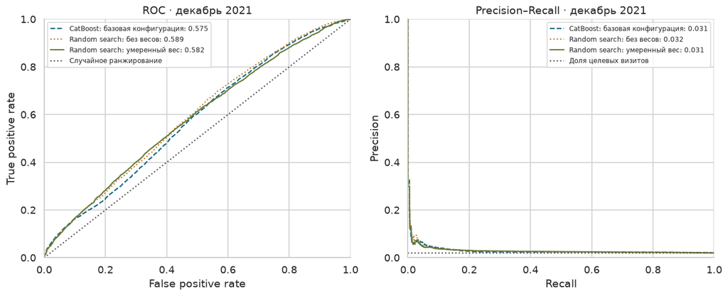

```python
test = pd.DataFrame(results['test']).T
print('Выбрана до оценки декабря:', selected)
display(test[columns+['predicted_positive_fraction']].astype(float).round(5))
ci = results['bootstrap']
display(Markdown(f"ROC-AUC выбранной модели: **{final['roc_auc']:.4f}**. Приближённый 95% интервал: **[{ci['auc_95'][0]:.4f}; {ci['auc_95'][1]:.4f}]**. Метод: 100 bootstrap-повторов с пересэмплированием клиентов целиком, чтобы связанные визиты не считались независимыми."))
display(Markdown(f"Парный 95% интервал разницы ROC-AUC с временным baseline: **[{ci['auc_difference_vs_temporal_baseline_95'][0]:.4f}; {ci['auc_difference_vs_temporal_baseline_95'][1]:.4f}]**. Если интервал включает 0, уверенного преимущества по этому эксперименту не установлено."))
curves = json.loads((ROOT/'reports/curves.json').read_text())
names = list(dict.fromkeys(['temporal_baseline','tuned_unweighted',selected]))
fig, axes = plt.subplots(1,2,figsize=(12,5))
for name,color,style in zip(names,COLORS,['--',':','-']):
    curve=curves[name]
    axes[0].plot(curve['fpr'],curve['tpr'],label=f"{LABELS[name]}: {results['test'][name]['roc_auc']:.3f}",color=color,linestyle=style)
    axes[1].step(curve['recall'],curve['precision'],where='post',label=f"{LABELS[name]}: {results['test'][name]['pr_auc_ap']:.3f}",color=color,linestyle=style)
axes[0].plot([0,1],[0,1],color='#555555',linestyle=':',label='Случайное ранжирование')
axes[1].axhline(results['split']['test']['positive_rate'],color='#555555',linestyle=':',label='Доля целевых визитов')
axes[0].set(title='ROC · декабрь 2021',xlabel='False positive rate',ylabel='True positive rate',xlim=(0,1),ylim=(0,1))
axes[1].set(title='Precision–Recall · декабрь 2021',xlabel='Recall',ylabel='Precision',xlim=(0,1),ylim=(0,1))
for ax in axes:ax.legend(fontsize=8)
savefig('13_december_curves')
```

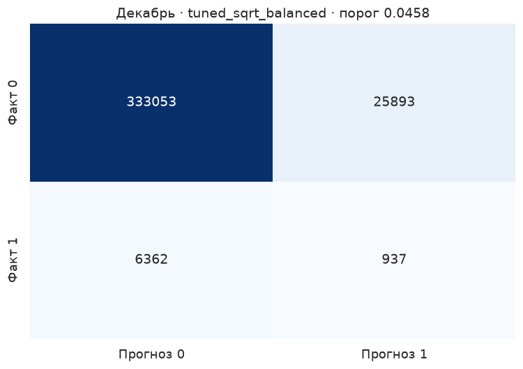

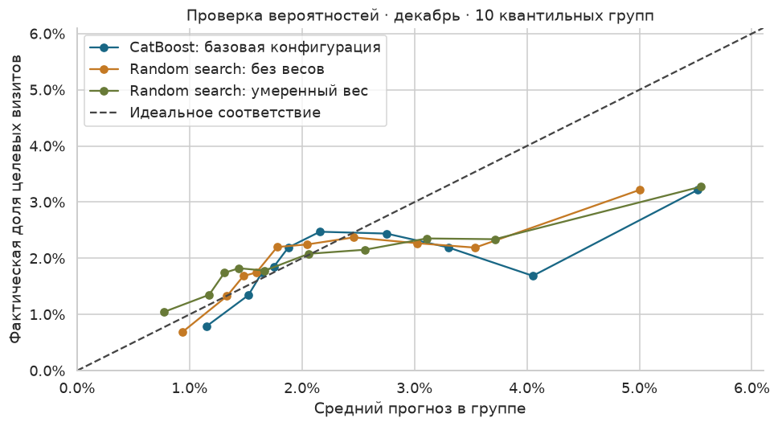

```
Поправка на веса — не гарантия откалиброванных вероятностей. Отклонения от диагонали показывают остаточное несоответствие.
```

```python
fig,ax=plt.subplots(figsize=(7,5))
sns.heatmap(final['confusion_matrix'],annot=True,fmt='d',cmap='Blues',cbar=False,ax=ax,
            xticklabels=['Прогноз 0','Прогноз 1'],yticklabels=['Факт 0','Факт 1'])
ax.set_title(f"Декабрь · {selected} · порог {final['threshold']:.4f}")
savefig('14_december_confusion')
calibration = pd.read_csv(ROOT/'reports/calibration.csv')
fig,ax=plt.subplots(figsize=(9,5))
for name,color in zip(names,COLORS):
    line=calibration.query('model == @name')
    ax.plot(line.mean_probability,line.observed_rate,marker='o',color=color,label=LABELS[name])
upper=max(calibration.loc[calibration.model.isin(names),['mean_probability','observed_rate']].max())*1.1
ax.plot([0,upper],[0,upper],linestyle='--',color='#444444',label='Идеальное соответствие')
ax.set(xlim=(0,upper),ylim=(0,upper),title='Проверка вероятностей · декабрь · 10 квантильных групп',xlabel='Средний прогноз в группе',ylabel='Фактическая доля целевых визитов')
ax.xaxis.set_major_formatter(PercentFormatter(1));ax.yaxis.set_major_formatter(PercentFormatter(1));ax.legend()
savefig('15_calibration')
print('Поправка на веса — не гарантия откалиброванных вероятностей. Отклонения от диагонали показывают остаточное несоответствие.')
```

```python
display(pd.DataFrame(results['test_client_cohorts']).T[columns+['rows','positive_rate']].astype(float).round(5))
weekly = pd.DataFrame(results['test_weekly']).T
weekly.index.name='week'
display(weekly[['rows','positive_rate','roc_auc','precision','recall']].astype(float).round(5))
print('new — клиент не встречался в мае–ноябре; returning — встречался. В обоих срезах декабрьские метки не были в обучении.')
```

|  | roc_auc | pr_auc_ap | precision | recall | f1 | threshold | brier_score | rows | positive_rate |
| --- | --- | --- | --- | --- | --- | --- | --- | --- | --- |
| new | 0.57890 | 0.02665 | 0.03265 | 0.11890 | 0.05123 | 0.0458 | 0.01914 | 341031.0 | 0.01946 |
| returning | 0.59991 | 0.08288 | 0.05558 | 0.22323 | 0.08900 | 0.0458 | 0.02517 | 25214.0 | 0.02629 |

| week | rows | positive_rate | roc_auc | precision | recall |
| --- | --- | --- | --- | --- | --- |
| 2021-11-29/2021-12-05 | 60504.0 | 0.01907 | 0.57941 | 0.03379 | 0.07106 |
| 2021-12-06/2021-12-12 | 77590.0 | 0.01962 | 0.55678 | 0.03238 | 0.07622 |
| 2021-12-13/2021-12-19 | 65200.0 | 0.02255 | 0.57683 | 0.04724 | 0.12109 |
| 2021-12-20/2021-12-26 | 100837.0 | 0.02167 | 0.57530 | 0.03394 | 0.22517 |
| 2021-12-27/2022-01-02 | 62114.0 | 0.01558 | 0.62048 | 0.02700 | 0.07128 |

```
new — клиент не встречался в мае–ноябре; returning — встречался. В обоих срезах декабрьские метки не были в обучении.
```

### Важность признаков

Перестановки выполняются на validation и все производные признаки пересчитываются. Это показывает вклад поля в качество выбранной модели, но не причинный эффект рекламы. Три перестановки на 12 000 визитов ноября; отрезки — стандартные отклонения, не доверительные интервалы.

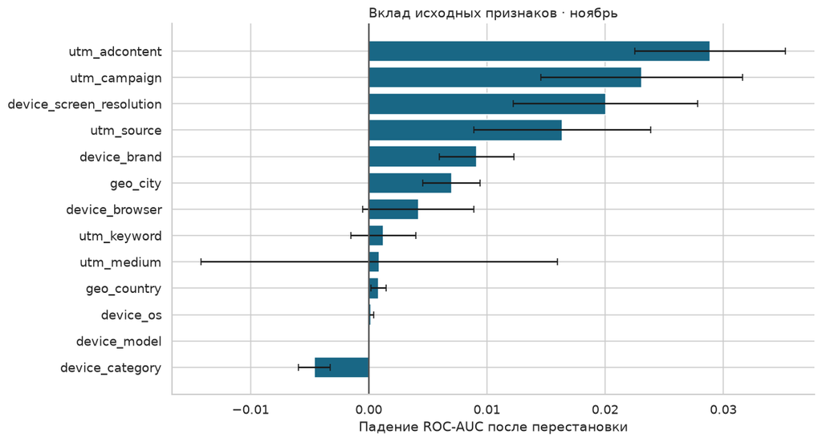

|  | feature | auc_drop_mean | auc_drop_std |
| --- | --- | --- | --- |
| 0 | utm_adcontent | 0.02887 | 0.00639 |
| 1 | utm_campaign | 0.02309 | 0.00854 |
| 2 | device_screen_resolution | 0.02003 | 0.00779 |
| 3 | utm_source | 0.01639 | 0.00747 |
| 4 | device_brand | 0.00912 | 0.00315 |
| 5 | geo_city | 0.00700 | 0.00245 |
| 6 | device_browser | 0.00419 | 0.00470 |
| 7 | utm_keyword | 0.00125 | 0.00275 |
| 8 | utm_medium | 0.00089 | 0.01507 |
| 9 | geo_country | 0.00084 | 0.00064 |
| 10 | device_os | 0.00020 | 0.00020 |
| 11 | device_model | 0.00000 | 0.00000 |
| 12 | device_category | -0.00462 | 0.00135 |

```python
importance = pd.read_csv(ROOT/'reports/permutation_importance.csv').sort_values('auc_drop_mean')
fig,ax=plt.subplots(figsize=(11,6))
ax.barh(importance.feature,importance.auc_drop_mean,xerr=importance.auc_drop_std,color=COLORS[0],capsize=3)
ax.axvline(0,color='#555555');ax.set(title='Вклад исходных признаков · ноябрь',xlabel='Падение ROC-AUC после перестановки',ylabel='')
savefig('16_temporal_importance')
display(importance.sort_values('auc_drop_mean',ascending=False).round(5))
```

## 7. Сервис и проверка воспроизводимости

Контракт API: `POST /predict` возвращает число 0 или 1; `/predict_proba` — класс, оценку вероятности и порог; `/predict_batch` обрабатывает до 1000 визитов. Модель и параметры преобразования загружаются один раз. Если побеждает взвешенная модель, та же поправка odds применяется в сервисе. Поддержана также загрузка логистического pipeline, чтобы выбор не был искусственно ограничен CatBoost.

Запуск: `python -m uvicorn app:app --host 127.0.0.1 --port 8035`. CLI: `python predict.py --input examples/session.json`. Проверки: `python -m unittest test_temporal test_service -v`. Полная инструкция — `README.md`.

Тесты охватывают границы месяцев, запрет попадания таргета/дат в признаки, явное временное разбиение RandomizedSearchCV, корректность поправки весов и порога, HTTP-входы и совпадение сохранённых декабрьских вероятностей с сервисом.

```python
from predict import Predictor
from fastapi.testclient import TestClient
from app import app
example=json.loads((ROOT/'examples/session.json').read_text())
with TestClient(app) as client:
    response=client.post('/predict',json=example)
    details=client.post('/predict_proba',json=example)
    assert response.status_code == details.status_code == 200
    assert response.json() == Predictor().predict([example])[0]
    print('POST /predict:',response.json())
    print('POST /predict_proba:',details.json())
benchmark_path=ROOT/'reports/api_benchmark.json'
if benchmark_path.exists():
    bench=json.loads(benchmark_path.read_text())
    display(pd.DataFrame({k:bench[k] for k in ['sequential','concurrent_8_clients']}).T.round(3))
    assert bench['mean_under_3_seconds']
else:
    print('Сетевой замер: запустить сервер, затем python benchmark.py.')
```

```
POST /predict: 0
POST /predict_proba: {'prediction': 0, 'probability': 0.032278815197606364, 'threshold': 0.04579872999909627}
```

|  | requests | mean_ms | p50_ms | p95_ms | max_ms |
| --- | --- | --- | --- | --- | --- |
| sequential | 100.0 | 5.564 | 5.397 | 6.477 | 7.065 |
| concurrent_8_clients | 100.0 | 37.839 | 38.432 | 40.296 | 41.092 |

## 8. Выводы

```python
baseline=results['test']['temporal_baseline']
tuned=results['test']['tuned_unweighted']
recall_mode=results['test_recall40_policy']
display(Markdown(f"""
- Временной тест: **{results['split']['test']['rows']:,} декабрьских визитов**, доля цели **{results['split']['test']['positive_rate']:.2%}**. Модель обучена только на май–октябрь.
- Проверены **6** конфигураций RandomizedSearchCV и **3** режима весов на полном train. Выбор зафиксирован по ноябрю: **{selected}**.
- ROC-AUC декабря: базовая конфигурация CatBoost **{baseline['roc_auc']:.4f}**, найденные настройки без весов **{tuned['roc_auc']:.4f}**, выбранная модель **{final['roc_auc']:.4f}**. Это сопоставимые оценки на одном тесте.
- Выбранная модель: AP **{final['pr_auc_ap']:.4f}**, precision **{final['precision']:.2%}**, recall **{final['recall']:.2%}**, F1 **{final['f1']:.4f}**.
- Дополнительный порог, рассчитанный для recall ≥40% на ноябре: на декабре precision **{recall_mode['precision']:.2%}**, recall **{recall_mode['recall']:.2%}**. Ценой большей полноты могут стать лишние обращения; без стоимости ошибок нельзя объявить этот режим лучшим для бизнеса.

**Что остаётся проверить:** более поздние данные; бизнес-стоимость пропуска целевого визита и ложного срабатывания; калибровка/порог после изменения конверсии. Даже выполненная временная проверка не доказывает качество на текущем трафике 2026 года.
"""))
```

- Временной тест: **366,245 декабрьских визитов**, доля цели **1.99%**. Модель обучена только на май–октябрь.

- Проверены **6** конфигураций RandomizedSearchCV и **3** режима весов на полном train. Выбор зафиксирован по ноябрю: **tuned_sqrt_balanced**.

- ROC-AUC декабря: базовая конфигурация CatBoost **0.5754**, найденные настройки без весов **0.5890**, выбранная модель **0.5821**. Это сопоставимые оценки на одном тесте.

- Выбранная модель: AP **0.0314**, precision **3.49%**, recall **12.84%**, F1 **0.0549**.

- Дополнительный порог, рассчитанный для recall ≥40% на ноябре: на декабре precision **2.82%**, recall **26.69%**. Ценой большей полноты могут стать лишние обращения; без стоимости ошибок нельзя объявить этот режим лучшим для бизнеса.

**Что остаётся проверить:** более поздние данные; бизнес-стоимость пропуска целевого визита и ложного срабатывания; калибровка/порог после изменения конверсии. Даже выполненная временная проверка не доказывает качество на текущем трафике 2026 года.